## **Part2**

In the second part, I plot the frequency of violations by the zip code in MA. Since it is also a large data, I split the data into 2 part. The zip codes are labeled on the graph and I use the package ggrepel so that the labels will not overlap. The color of the label represents the type of violations and it is demonstrated on the right side of the graph.

```r
#I choose to plot the violation types in Boston by zipcode
Boston <- final[final$name=="BOSTON",]
Boston <- arrange(select(Boston,Zipcode, violType, viol_Freq), Zipcode)
#Obmit the NA rows
Boston <- na.omit(Boston)
#find the frequency of each violation type for each Zipcode
Boston <- ddply(Boston, .(Zipcode,violType), summarise, viol_Freq = sum(viol_Freq))

#Since the data is too large, I separate it into 2 parts
P1 <- Boston[1:100,]
P2 <- Boston[101:276,]
```

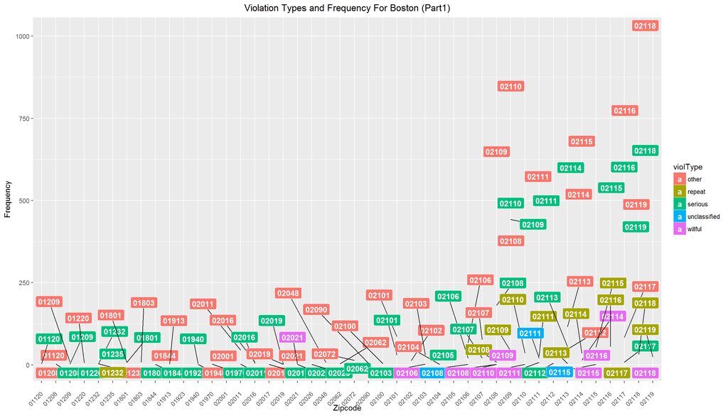

```r
#Plot the data
require(ggrepel)
ggplot(P1, aes(Zipcode, viol_Freq, label=Zipcode))+ geom_label_repel(aes(fill=violType), colour="white", fontface="bold",segment.color='black') + theme(plot.title = element_text(hjust = 0.5),axis.text.x=element_text(angle=45,hjust=1,vjust=0.5)) + ggtitle("Violation Types and Frequency For Boston (Part1)") + ylab("Frequency")
```

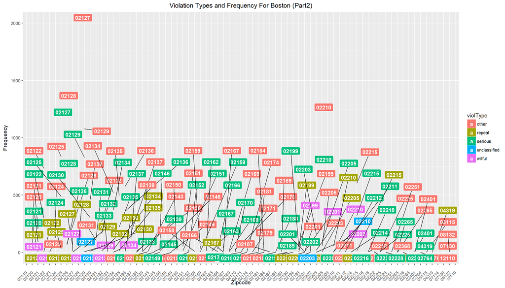

```r
ggplot(P2, aes(Zipcode, viol_Freq, label=Zipcode))+ geom_label_repel(aes(fill=violType), colour="white", fontface="bold",segment.color='black') + theme(plot.title = element_text(hjust = 0.5),axis.text.x=element_text(angle=45,hjust=1,vjust=0.5)) + ggtitle("Violation Types and Frequency For Boston (Part2)") + ylab("Frequency")
```

It is clear that there are some places that have more violations that happen, and it is easy to find which type of violation it is by looking at the color. Notice that the x-axis is the zipcode but it does not mean any numeric values. It is just for convience because in this way I can plot the data by the order of zip code.